# Telco Churn Kaggle Dataset: Analysis with FastAI Workflow

### Preamble

This data is from IBM's collection of sample data, and represents data about a number of customers from a telecom company. The goal is to predict customer churn based on the customer data provided.

Each row represents a customer, each column contains customer’s attributes described on the column Metadata. The raw data contains 7043 rows (customers) and 21 columns (features). The “Churn” column is our target.

Note: This analysis follows the workflow described in the [FastAI ML course](http://course.fast.ai/ml.html), using random forests to both predict the outcome and analyze feature importance.

## Examining the Data

### Loading in the dataset

Before we can do anything we should load in the data from the .csv that contains it.

```python
%load_ext autoreload
%autoreload 2
%matplotlib inline

import pandas as pd
import numpy as np

df_raw = pd.read_csv('WA_Fn-UseC_-Telco-Customer-Churn.csv')
```

### Looking at raw data and summary statistics

It's crucial that we take a look at the data to understand what it looks like before we start to do anything with it. We should also not do anything to it in this step, as we don't want to influence the analysis down the road with our biases. It's better to let the model take care of removing irrelevant details, and to identify potential sources of data leakage, unless we're sure that something in our data represents something unavailable at prediction time in the real world.

```python
def display_all(df):
    with pd.option_context("display.max_rows", 1000, "display.max_columns", 1000):
        display(df)
```

```python
display_all(df_raw.tail().T)
```

|  | 7038 | 7039 | 7040 | 7041 | 7042 |
| --- | --- | --- | --- | --- | --- |
| customerID | 6840-RESVB | 2234-XADUH | 4801-JZAZL | 8361-LTMKD | 3186-AJIEK |
| gender | Male | Female | Female | Male | Male |
| SeniorCitizen | 0 | 0 | 0 | 1 | 0 |
| Partner | Yes | Yes | Yes | Yes | No |
| Dependents | Yes | Yes | Yes | No | No |
| tenure | 24 | 72 | 11 | 4 | 66 |
| PhoneService | Yes | Yes | No | Yes | Yes |
| MultipleLines | Yes | Yes | No phone service | Yes | No |
| InternetService | DSL | Fiber optic | DSL | Fiber optic | Fiber optic |
| OnlineSecurity | Yes | No | Yes | No | Yes |
| OnlineBackup | No | Yes | No | No | No |
| DeviceProtection | Yes | Yes | No | No | Yes |
| TechSupport | Yes | No | No | No | Yes |
| StreamingTV | Yes | Yes | No | No | Yes |
| StreamingMovies | Yes | Yes | No | No | Yes |
| Contract | One year | One year | Month-to-month | Month-to-month | Two year |
| PaperlessBilling | Yes | Yes | Yes | Yes | Yes |
| PaymentMethod | Mailed check | Credit card (automatic) | Electronic check | Mailed check | Bank transfer (automatic) |
| MonthlyCharges | 84.8 | 103.2 | 29.6 | 74.4 | 105.65 |
| TotalCharges | 1990.5 | 7362.9 | 346.45 | 306.6 | 6844.5 |
| Churn | No | No | No | Yes | No |

```python
display_all(df_raw.describe(include='all').T)
```

|  | count | unique | top | freq | mean | std | min | 25% | 50% | 75% | max |
| --- | --- | --- | --- | --- | --- | --- | --- | --- | --- | --- | --- |
| customerID | 7043 | 7043 | 9800-ONTFE | 1 | NaN | NaN | NaN | NaN | NaN | NaN | NaN |
| gender | 7043 | 2 | Male | 3555 | NaN | NaN | NaN | NaN | NaN | NaN | NaN |
| SeniorCitizen | 7043 | NaN | NaN | NaN | 0.162147 | 0.368612 | 0 | 0 | 0 | 0 | 1 |
| Partner | 7043 | 2 | No | 3641 | NaN | NaN | NaN | NaN | NaN | NaN | NaN |
| Dependents | 7043 | 2 | No | 4933 | NaN | NaN | NaN | NaN | NaN | NaN | NaN |
| tenure | 7043 | NaN | NaN | NaN | 32.3711 | 24.5595 | 0 | 9 | 29 | 55 | 72 |
| PhoneService | 7043 | 2 | Yes | 6361 | NaN | NaN | NaN | NaN | NaN | NaN | NaN |
| MultipleLines | 7043 | 3 | No | 3390 | NaN | NaN | NaN | NaN | NaN | NaN | NaN |
| InternetService | 7043 | 3 | Fiber optic | 3096 | NaN | NaN | NaN | NaN | NaN | NaN | NaN |
| OnlineSecurity | 7043 | 3 | No | 3498 | NaN | NaN | NaN | NaN | NaN | NaN | NaN |
| OnlineBackup | 7043 | 3 | No | 3088 | NaN | NaN | NaN | NaN | NaN | NaN | NaN |
| DeviceProtection | 7043 | 3 | No | 3095 | NaN | NaN | NaN | NaN | NaN | NaN | NaN |
| TechSupport | 7043 | 3 | No | 3473 | NaN | NaN | NaN | NaN | NaN | NaN | NaN |
| StreamingTV | 7043 | 3 | No | 2810 | NaN | NaN | NaN | NaN | NaN | NaN | NaN |
| StreamingMovies | 7043 | 3 | No | 2785 | NaN | NaN | NaN | NaN | NaN | NaN | NaN |
| Contract | 7043 | 3 | Month-to-month | 3875 | NaN | NaN | NaN | NaN | NaN | NaN | NaN |
| PaperlessBilling | 7043 | 2 | Yes | 4171 | NaN | NaN | NaN | NaN | NaN | NaN | NaN |
| PaymentMethod | 7043 | 4 | Electronic check | 2365 | NaN | NaN | NaN | NaN | NaN | NaN | NaN |
| MonthlyCharges | 7043 | NaN | NaN | NaN | 64.7617 | 30.09 | 18.25 | 35.5 | 70.35 | 89.85 | 118.75 |
| TotalCharges | 7043 | 6531 | 20.2 | 11 | NaN | NaN | NaN | NaN | NaN | NaN | NaN |
| Churn | 7043 | 2 | No | 5174 | NaN | NaN | NaN | NaN | NaN | NaN | NaN |

```python
df_raw.info()
```

```
<class 'pandas.core.frame.DataFrame'>
RangeIndex: 7043 entries, 0 to 7042
Data columns (total 21 columns):
customerID          7043 non-null object
gender              7043 non-null object
SeniorCitizen       7043 non-null int64
Partner             7043 non-null object
Dependents          7043 non-null object
tenure              7043 non-null int64
PhoneService        7043 non-null object
MultipleLines       7043 non-null object
InternetService     7043 non-null object
OnlineSecurity      7043 non-null object
OnlineBackup        7043 non-null object
DeviceProtection    7043 non-null object
TechSupport         7043 non-null object
StreamingTV         7043 non-null object
StreamingMovies     7043 non-null object
Contract            7043 non-null object
PaperlessBilling    7043 non-null object
PaymentMethod       7043 non-null object
MonthlyCharges      7043 non-null float64
TotalCharges        7043 non-null object
Churn               7043 non-null object
dtypes: float64(1), int64(2), object(18)
memory usage: 1.1+ MB
```

From this we can notice a few things. The first is that `customerID` is most likely not a useful column for the prediction, as it might be a randomly-generated ID that has no bearing on whether or not a customer will leave. However, we can leave it in as random forests will automatically disregard unimportant features.

The second thing we notice is that `TotalCharges` appears to be a numerical column, but pandas is treating it as `object` for some reason. Also, there are no null rows.

Thirdly, `SeniorCitizen` is being treated as a numerical column of type `int64`, but we can see it simply contains a boolean value of 0 or 1 depending on whether the customer is a SeniorCitizen or not. We should convert this back to a categorical variable, with levels `Yes` and `No` for human readability, then when we process the entire dataframe it will be transformed under the hood back into 0s and 1s.

## Preparing data for random forest classification

### Dealing with TotalCharges

Since there are no null rows found by pandas in the `TotalCharges` column, one thing we can do is look for any rows that contain whitespace characters, which would get interpreted as strings and force the entire column to be coerced to `object` type.

```python
cols =  pd.DataFrame({col_name : sum([int(str(elem).isspace() == True) \
                                 for elem in col]) for col_name, col in df_raw.iteritems()}, index=[0])
cols = cols.rename(index={cols.index[0]: 'whitespace-only rows'}); cols.T
```

|  | whitespace-only rows |
| --- | --- |
| customerID | 0 |
| gender | 0 |
| SeniorCitizen | 0 |
| Partner | 0 |
| Dependents | 0 |
| tenure | 0 |
| PhoneService | 0 |
| MultipleLines | 0 |
| InternetService | 0 |
| OnlineSecurity | 0 |
| OnlineBackup | 0 |
| DeviceProtection | 0 |
| TechSupport | 0 |
| StreamingTV | 0 |
| StreamingMovies | 0 |
| Contract | 0 |
| PaperlessBilling | 0 |
| PaymentMethod | 0 |
| MonthlyCharges | 0 |
| TotalCharges | 11 |
| Churn | 0 |

There are indeed 11 whitespace-only rows in the `TotalCharges` column. We should take a look at these rows to see if we can see why they are blank and decide how we're going to handle them.

```python
whitespace_rows = df_raw[df_raw['TotalCharges'].str.isspace()]; whitespace_rows
```

|  | customerID | gender | SeniorCitizen | Partner | Dependents | tenure | PhoneService | MultipleLines | InternetService | OnlineSecurity | ... | DeviceProtection | TechSupport | StreamingTV | StreamingMovies | Contract | PaperlessBilling | PaymentMethod | MonthlyCharges | TotalCharges | Churn |
| --- | --- | --- | --- | --- | --- | --- | --- | --- | --- | --- | --- | --- | --- | --- | --- | --- | --- | --- | --- | --- | --- |
| 488 | 4472-LVYGI | Female | 0 | Yes | Yes | 0 | No | No phone service | DSL | Yes | ... | Yes | Yes | Yes | No | Two year | Yes | Bank transfer (automatic) | 52.55 |  | No |
| 753 | 3115-CZMZD | Male | 0 | No | Yes | 0 | Yes | No | No | No internet service | ... | No internet service | No internet service | No internet service | No internet service | Two year | No | Mailed check | 20.25 |  | No |
| 936 | 5709-LVOEQ | Female | 0 | Yes | Yes | 0 | Yes | No | DSL | Yes | ... | Yes | No | Yes | Yes | Two year | No | Mailed check | 80.85 |  | No |
| 1082 | 4367-NUYAO | Male | 0 | Yes | Yes | 0 | Yes | Yes | No | No internet service | ... | No internet service | No internet service | No internet service | No internet service | Two year | No | Mailed check | 25.75 |  | No |
| 1340 | 1371-DWPAZ | Female | 0 | Yes | Yes | 0 | No | No phone service | DSL | Yes | ... | Yes | Yes | Yes | No | Two year | No | Credit card (automatic) | 56.05 |  | No |
| 3331 | 7644-OMVMY | Male | 0 | Yes | Yes | 0 | Yes | No | No | No internet service | ... | No internet service | No internet service | No internet service | No internet service | Two year | No | Mailed check | 19.85 |  | No |
| 3826 | 3213-VVOLG | Male | 0 | Yes | Yes | 0 | Yes | Yes | No | No internet service | ... | No internet service | No internet service | No internet service | No internet service | Two year | No | Mailed check | 25.35 |  | No |
| 4380 | 2520-SGTTA | Female | 0 | Yes | Yes | 0 | Yes | No | No | No internet service | ... | No internet service | No internet service | No internet service | No internet service | Two year | No | Mailed check | 20.00 |  | No |
| 5218 | 2923-ARZLG | Male | 0 | Yes | Yes | 0 | Yes | No | No | No internet service | ... | No internet service | No internet service | No internet service | No internet service | One year | Yes | Mailed check | 19.70 |  | No |
| 6670 | 4075-WKNIU | Female | 0 | Yes | Yes | 0 | Yes | Yes | DSL | No | ... | Yes | Yes | Yes | No | Two year | No | Mailed check | 73.35 |  | No |
| 6754 | 2775-SEFEE | Male | 0 | No | Yes | 0 | Yes | Yes | DSL | Yes | ... | No | Yes | No | No | Two year | Yes | Bank transfer (automatic) | 61.90 |  | No |

11 rows × 21 columns

The main thing to notice that these rows have in common is that none of these customers have churned, and they all have a tenure of 0, indicating that they have not been with the company for one month yet. Now we can infer that `TotalCharges` is blank because they have not been charged anything yet as a result of not being around for a month yet. We could remove these rows, but knowing this I think it makes more sense to replace the `TotalCharges` with 0 and keep them in.

```python
df_raw['TotalCharges'].replace(r'^\s+$', 0, regex=True, inplace=True)
df_raw['TotalCharges'] = df_raw['TotalCharges'].astype('float64')
df_raw['TotalCharges'].iloc[488]
```

```
0.0
```

### Relabeling SeniorCitizen

To fix the SeniorCitizen column, we can replace values of `1` with `'Yes'` and `0` with `'No'`.

```python
df_raw['SeniorCitizen'] = df_raw['SeniorCitizen'].apply(lambda row : (row == 1 and 'Yes') or (row == 0 and 'No'))
df_raw['SeniorCitizen'].tail()
```

```
7038     No
7039     No
7040     No
7041    Yes
7042     No
Name: SeniorCitizen, dtype: object
```

Then we can coerce the column to type `object` once more for the purposes of our downstream data processing steps.

```python
df_raw['SeniorCitizen'] = df_raw['SeniorCitizen'].astype('object')
df_raw.info()
```

```
<class 'pandas.core.frame.DataFrame'>
RangeIndex: 7043 entries, 0 to 7042
Data columns (total 21 columns):
customerID          7043 non-null object
gender              7043 non-null object
SeniorCitizen       7043 non-null object
Partner             7043 non-null object
Dependents          7043 non-null object
tenure              7043 non-null int64
PhoneService        7043 non-null object
MultipleLines       7043 non-null object
InternetService     7043 non-null object
OnlineSecurity      7043 non-null object
OnlineBackup        7043 non-null object
DeviceProtection    7043 non-null object
TechSupport         7043 non-null object
StreamingTV         7043 non-null object
StreamingMovies     7043 non-null object
Contract            7043 non-null object
PaperlessBilling    7043 non-null object
PaymentMethod       7043 non-null object
MonthlyCharges      7043 non-null float64
TotalCharges        7043 non-null float64
Churn               7043 non-null object
dtypes: float64(2), int64(1), object(18)
memory usage: 1.1+ MB
```

### Converting object columns into categories

```python
from pandas.api.types import is_numeric_dtype
for n,c in df_raw.items():
    if not is_numeric_dtype(c):
        df_raw[n] = (c.astype('category').cat.as_ordered()).cat.codes
df_raw.info()
```

```
<class 'pandas.core.frame.DataFrame'>
RangeIndex: 7043 entries, 0 to 7042
Data columns (total 21 columns):
customerID          7043 non-null int16
gender              7043 non-null int8
SeniorCitizen       7043 non-null int8
Partner             7043 non-null int8
Dependents          7043 non-null int8
tenure              7043 non-null int64
PhoneService        7043 non-null int8
MultipleLines       7043 non-null int8
InternetService     7043 non-null int8
OnlineSecurity      7043 non-null int8
OnlineBackup        7043 non-null int8
DeviceProtection    7043 non-null int8
TechSupport         7043 non-null int8
StreamingTV         7043 non-null int8
StreamingMovies     7043 non-null int8
Contract            7043 non-null int8
PaperlessBilling    7043 non-null int8
PaymentMethod       7043 non-null int8
MonthlyCharges      7043 non-null float64
TotalCharges        7043 non-null float64
Churn               7043 non-null int8
dtypes: float64(2), int16(1), int64(1), int8(17)
memory usage: 295.8 KB
```

### One-hot encoding categorical variables

We can also one-hot encode some of the multi-level categorical variables in order to better flesh out which ones are most important for distinguishing between churn and no churn. For instance, it might be good to know specifically which type of `Contract` is most predictive of `Churn`.

```python
df_raw = pd.get_dummies(df_raw, columns=['Contract'])
df_raw.rename(columns={'Contract_0':'Contract_month_to_month',
                       'Contract_1':'Contract_one_year', 'Contract_2':'Contract_two_year'}, inplace=True)
display_all(df_raw.tail().T)
```

|  | 7038 | 7039 | 7040 | 7041 | 7042 |
| --- | --- | --- | --- | --- | --- |
| customerID | 4853.0 | 1525.0 | 3367.00 | 5934.0 | 2226.00 |
| gender | 1.0 | 0.0 | 0.00 | 1.0 | 1.00 |
| SeniorCitizen | 0.0 | 0.0 | 0.00 | 1.0 | 0.00 |
| Partner | 1.0 | 1.0 | 1.00 | 1.0 | 0.00 |
| Dependents | 1.0 | 1.0 | 1.00 | 0.0 | 0.00 |
| tenure | 24.0 | 72.0 | 11.00 | 4.0 | 66.00 |
| PhoneService | 1.0 | 1.0 | 0.00 | 1.0 | 1.00 |
| MultipleLines | 2.0 | 2.0 | 1.00 | 2.0 | 0.00 |
| InternetService | 0.0 | 1.0 | 0.00 | 1.0 | 1.00 |
| OnlineSecurity | 2.0 | 0.0 | 2.00 | 0.0 | 2.00 |
| OnlineBackup | 0.0 | 2.0 | 0.00 | 0.0 | 0.00 |
| DeviceProtection | 2.0 | 2.0 | 0.00 | 0.0 | 2.00 |
| TechSupport | 2.0 | 0.0 | 0.00 | 0.0 | 2.00 |
| StreamingTV | 2.0 | 2.0 | 0.00 | 0.0 | 2.00 |
| StreamingMovies | 2.0 | 2.0 | 0.00 | 0.0 | 2.00 |
| PaperlessBilling | 1.0 | 1.0 | 1.00 | 1.0 | 1.00 |
| PaymentMethod | 3.0 | 1.0 | 2.00 | 3.0 | 0.00 |
| MonthlyCharges | 84.8 | 103.2 | 29.60 | 74.4 | 105.65 |
| TotalCharges | 1990.5 | 7362.9 | 346.45 | 306.6 | 6844.50 |
| Churn | 0.0 | 0.0 | 0.00 | 1.0 | 0.00 |
| Contract_month_to_month | 0.0 | 0.0 | 1.00 | 1.0 | 0.00 |
| Contract_one_year | 1.0 | 1.0 | 0.00 | 0.0 | 0.00 |
| Contract_two_year | 0.0 | 0.0 | 0.00 | 0.0 | 1.00 |

### Saving our dataframe in feather format

```python
# df_index = df_raw.index
# df_raw.reset_index(drop=True, inplace=True)
df_raw.to_feather('telco_churn_raw')
```

### Creating training, validation, and test sets

```python
def split_vals(a,n):
    return a[:n].copy(), a[n:].copy()

# Shuffle the dataframe in place by taking a random sample with the same size as the original dataset
df_raw.sample(frac=1)
df_train, df_test = split_vals(df_raw, 5500)
df_train.shape, df_test.shape
```

```
((5500, 23), (1543, 23))
```

```python
X, y = df_test.drop('Churn', axis=1), df_test['Churn']
```

Now we can split those up into training, validation, and test sets. The test set will be used at the end to give the final evaluation of the model's accuracy after parameter tuning using the validation set.

```python
from sklearn.model_selection import train_test_split

X_val, X_test, y_val, y_test = train_test_split(X, y, test_size = 0.5, stratify=y)
X_val.shape, X_test.shape
```

```
((771, 22), (772, 22))
```

### Upsampling the positive "Churn" instances to even out the target distribution

```python
df_train.groupby('Churn').size()
```

```
Churn
0    4052
1    1448
dtype: int64
```

We have approximately one churn instance to every three no churn instances. To even out the target distribution and avoid overpredicting no churn due to our imbalanced dataset, we use bootstrap resampling to upsample the minority class to get an even target distribution between "Churn" and "No churn" groups.

To do this, we split the dataset according to the target and then resample the minority class to be the same size as the majority class, then combine the two to form a new, balanced training set.

```python
df_no = df_train[df_train['Churn'] == 0]
df_yes = df_train[df_train['Churn'] == 1]
from sklearn.utils import resample
df_yes_ups = resample(df_yes, replace=True, n_samples=len(df_no))
df_train = pd.concat([df_yes_ups, df_no])
df_train.Churn.value_counts()
```

```
1    4052
0    4052
Name: Churn, dtype: int64
```

Now we can split this training set dataframe into independent and dependent variables and proceed with our analysis.

```python
X_train, y_train = df_train.drop('Churn', axis=1), df_train['Churn']
```

## Analyzing feature importance with random forests

### Training our first random forest

Now that we have our training, validation, and test sets, we can move on to create a simple random forest classifier to get a sense of how well we can do without much parameter tuning, and be able to move on to the feature importance analysis.

```python
from sklearn.ensemble import RandomForestClassifier

m = RandomForestClassifier(n_estimators=60, min_samples_leaf=5, max_features=0.5, n_jobs=-1, oob_score=True)
m.fit(X_train, y_train)
```

```
RandomForestClassifier(bootstrap=True, class_weight=None, criterion='gini',
            max_depth=None, max_features=0.5, max_leaf_nodes=None,
            min_impurity_decrease=0.0, min_impurity_split=None,
            min_samples_leaf=5, min_samples_split=2,
            min_weight_fraction_leaf=0.0, n_estimators=60, n_jobs=-1,
            oob_score=True, random_state=None, verbose=0, warm_start=False)
```

```python
def print_score(m):
    res = [m.score(X_train, y_train), m.score(X_val, y_val), m.oob_score_]
    print(res)

print_score(m)
```

```
[0.9463228035538006, 0.7898832684824902, 0.8667324777887463]
```

We can see that our first attempt is heavily overfitting to the training data.

### Using subsampling to reduce overfitting

One way to reduce overfitting and also reduce training time is to use the FastAI function `set_rf_samples()`, which will allow each of the trees to train on a different subsample of the training dataset we give it, such that overall the trees together will see the entire training set, but individually only see part of it.

```python
from sklearn.ensemble import forest

def set_rf_samples(n):
    """ Changes Scikit learn's random forests to give each tree a random sample of
    n random rows.
    """
    forest._generate_sample_indices = (lambda rs, n_samples:
        forest.check_random_state(rs).randint(0, n_samples, n))
```

```python
set_rf_samples(1500)
```

```python
m = RandomForestClassifier(n_estimators=40, min_samples_leaf=1, max_features='sqrt', n_jobs=-1, oob_score=True)
m.fit(X_train, y_train)
print_score(m)
```

```
[0.9016535044422508, 0.7782101167315175, 0.8435340572556762]
```

### Tuning the parameters with GridSearchCV

We can try and rectify this overfitting using a grid search to search for better parameters for our model.

```python
params = {
    'min_samples_leaf': [1, 3, 5, 10, 25, 100],
    'max_features': ['sqrt', 'log2', 0.5, 1]
}

from sklearn.model_selection import GridSearchCV

rf = RandomForestClassifier(n_estimators=40, oob_score=True)
grid = GridSearchCV(rf, param_grid=params, scoring='f1', n_jobs=-1)
grid.fit(X_train, y_train)
grid.best_params_
```

```
{'max_features': 'log2', 'min_samples_leaf': 1}
```

### Looking at feature importance

We should take a look at the feature importance of the different features to see if one of them is dominating the pack and perhaps could be contributing to the overfitting we're seeing.

```python
# From the fastai library
def rf_feat_importance(m, df):
    return pd.DataFrame({'cols':df.columns, 'imp':m.feature_importances_}
                       ).sort_values('imp', ascending=False)

fi = rf_feat_importance(m, X); fi
```

|  | cols | imp |
| --- | --- | --- |
| 5 | tenure | 0.135169 |
| 17 | MonthlyCharges | 0.128455 |
| 18 | TotalCharges | 0.124420 |
| 0 | customerID | 0.109156 |
| 19 | Contract_month_to_month | 0.073036 |
| 12 | TechSupport | 0.050357 |
| 16 | PaymentMethod | 0.044712 |
| 21 | Contract_two_year | 0.042559 |
| 8 | InternetService | 0.040262 |
| 9 | OnlineSecurity | 0.037758 |
| 15 | PaperlessBilling | 0.024880 |
| 10 | OnlineBackup | 0.023515 |
| 11 | DeviceProtection | 0.022652 |
| 1 | gender | 0.022396 |
| 3 | Partner | 0.018868 |
| 7 | MultipleLines | 0.018459 |
| 4 | Dependents | 0.017910 |
| 14 | StreamingMovies | 0.016497 |
| 2 | SeniorCitizen | 0.015537 |
| 20 | Contract_one_year | 0.014256 |
| 13 | StreamingTV | 0.014125 |
| 6 | PhoneService | 0.005021 |

Now we see that perhaps we made a mistake in keeping `customerID` among our features, since it's top 4 in terms of feature importance, which should not be the case if it's just a random ID with no bearing on the outcome. We should try removing it and see how that changes the feature importance.

```python
def drop_cols(colnames):
    for df in [X_train, X_val, X_test, X]:
        df.drop(colnames, axis=1, inplace=True)
drop_cols('customerID')
X_train.tail()
```

|  | gender | SeniorCitizen | Partner | Dependents | tenure | PhoneService | MultipleLines | InternetService | OnlineSecurity | OnlineBackup | ... | TechSupport | StreamingTV | StreamingMovies | PaperlessBilling | PaymentMethod | MonthlyCharges | TotalCharges | Contract_month_to_month | Contract_one_year | Contract_two_year |
| --- | --- | --- | --- | --- | --- | --- | --- | --- | --- | --- | --- | --- | --- | --- | --- | --- | --- | --- | --- | --- | --- |
| 5489 | 0 | 0 | 0 | 1 | 11 | 0 | 1 | 0 | 0 | 0 | ... | 0 | 0 | 0 | 0 | 2 | 25.20 | 321.05 | 1 | 0 | 0 |
| 5490 | 1 | 0 | 0 | 0 | 6 | 1 | 0 | 0 | 2 | 2 | ... | 0 | 0 | 0 | 1 | 0 | 55.70 | 335.65 | 1 | 0 | 0 |
| 5491 | 1 | 0 | 0 | 0 | 21 | 1 | 0 | 0 | 2 | 0 | ... | 0 | 2 | 0 | 0 | 0 | 65.35 | 1424.40 | 1 | 0 | 0 |
| 5492 | 0 | 0 | 1 | 1 | 65 | 1 | 2 | 2 | 1 | 1 | ... | 1 | 1 | 1 | 1 | 0 | 25.30 | 1748.55 | 0 | 0 | 1 |
| 5496 | 1 | 0 | 1 | 1 | 43 | 1 | 2 | 2 | 1 | 1 | ... | 1 | 1 | 1 | 0 | 3 | 24.25 | 1077.95 | 0 | 0 | 1 |

5 rows × 21 columns

```python
m = RandomForestClassifier(n_estimators=60, min_samples_leaf=1, max_features='sqrt', n_jobs=-1, oob_score=True)
m.fit(X_train, y_train)
print_score(m)
```

```
[0.9090572556762093, 0.7639429312581063, 0.8473593287265548]
```

```python
fi = rf_feat_importance(m, X); fi
```

|  | cols | imp |
| --- | --- | --- |
| 16 | MonthlyCharges | 0.153929 |
| 17 | TotalCharges | 0.152254 |
| 4 | tenure | 0.139023 |
| 18 | Contract_month_to_month | 0.088774 |
| 8 | OnlineSecurity | 0.055785 |
| 15 | PaymentMethod | 0.049706 |
| 11 | TechSupport | 0.049659 |
| 20 | Contract_two_year | 0.035650 |
| 7 | InternetService | 0.031902 |
| 14 | PaperlessBilling | 0.027589 |
| 9 | OnlineBackup | 0.027423 |
| 0 | gender | 0.024852 |
| 6 | MultipleLines | 0.022579 |
| 10 | DeviceProtection | 0.022361 |
| 2 | Partner | 0.021751 |
| 1 | SeniorCitizen | 0.018906 |
| 12 | StreamingTV | 0.018751 |
| 13 | StreamingMovies | 0.018450 |
| 3 | Dependents | 0.018245 |
| 19 | Contract_one_year | 0.015263 |
| 5 | PhoneService | 0.007147 |

### Removing redundant features with hierarchical clustering

We can see that some of these features are likely related to one another, and so we can try removing some of them to see if our performance improves and if our feature importance makes more sense. Right now we can see `MonthlyCharges`, `TotalCharges`, and `tenure` are dominating nearly 50% of the feature importance, but `TotalCharges` is really highly correlated with `MonthlyCharges` and `tenure`, since it's really the product of those two plus or minus some discrepancy.

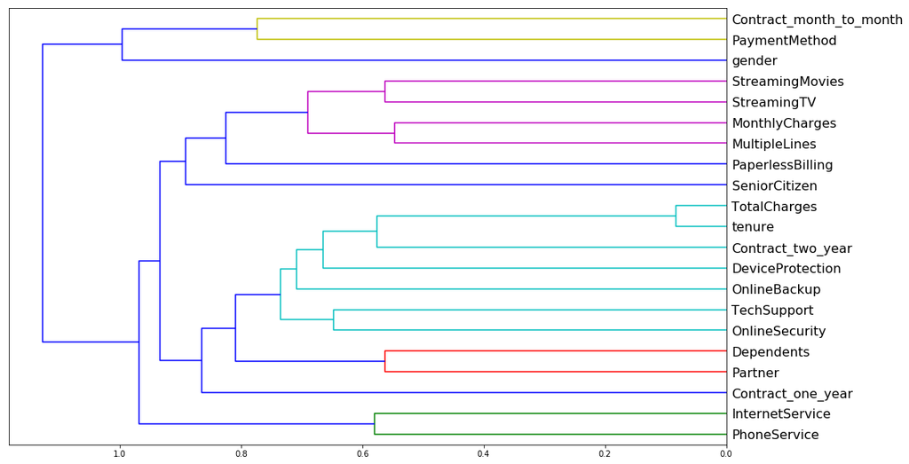

```python
import scipy
import matplotlib.pyplot as plt
from scipy.cluster import hierarchy as hc

corr = np.round(scipy.stats.spearmanr(X_train).correlation, 4)
corr_condensed = hc.distance.squareform(1-corr)
z = hc.linkage(corr_condensed, method='average')
fig = plt.figure(figsize=(16,10))
dendrogram = hc.dendrogram(z, labels=X_train.columns, orientation='left', leaf_font_size=16)
plt.show()
```

As we can see from the hierarchical clustering, `TotalCharges` and `tenure` are very closely correlated, and so we should probably remove `TotalCharges` to remove a source of collinearity in the model.

`Contract` is also closely related, which is interesting, since it suggests that the `tenure` with a company does depend heavily on whether they're on a month-to-month, one-year or two-year contract. This is worth exploring in further detail.

Not surprisingly, `Dependents` and `Partner` are also correlated, which makes sense considering that people who have kids often have a partner they had kids with.

```python
drop_cols(['TotalCharges', 'PhoneService', 'StreamingTV', 'DeviceProtection'])
```

```python
m = RandomForestClassifier(n_estimators=60, min_samples_leaf=1, max_features=0.5, n_jobs=-1, oob_score=True)
m.fit(X_train, y_train)
print_score(m)
```

```
[0.903751233958539, 0.7769130998702983, 0.8471125370187562]
```

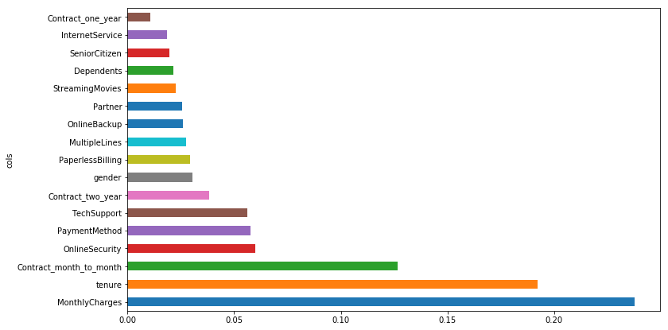

```python
fi = rf_feat_importance(m, X)
def plot_fi(fi):
    return fi.plot('cols', 'imp', 'barh', figsize=(12,7), legend=False)
plot_fi(fi)
```

### Partial dependence plots

One way to examine the effects of some of these variables on the `Churn` outcome is to do some pairwise plots. These have the limitation, however, of potentially showing effects that are produced by other variables, leading to false conclusions about the relationship between the independent and dependent variables.

We can avoid this by using something called a partial dependence plot, where we set the values in a particular column all to the same level, then see what the predictions would look like with all other variables kept equal.

```python
from pdpbox import pdp

def plot_pdp(feat, clusters=None, feat_name=None):
    feat_name = feat_name or feat
    p = pdp.pdp_isolate(m, X_train, list(X_train), feat)
    return pdp.pdp_plot(p, feat_name, plot_lines=True,
                        cluster=clusters is not None, n_cluster_centers=clusters)
```

```
(<Figure size 1080x684 with 2 Axes>,
 {'title_ax': <matplotlib.axes._subplots.AxesSubplot at 0x207c0953668>,
  'pdp_ax': <matplotlib.axes._subplots.AxesSubplot at 0x207c0b9def0>})
```

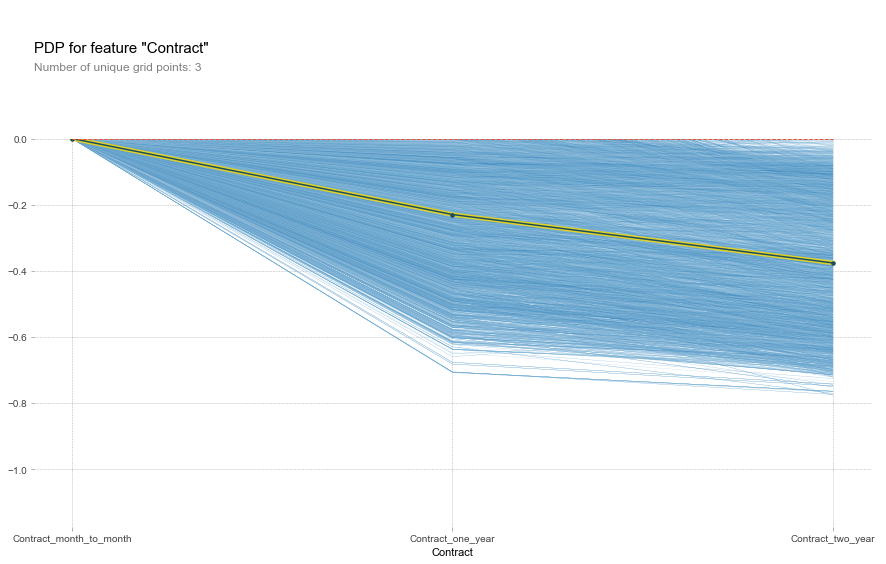

```python
plot_pdp(['Contract_month_to_month', 'Contract_one_year', 'Contract_two_year'], None, 'Contract')
```

```
(<Figure size 1080x684 with 2 Axes>,
 {'title_ax': <matplotlib.axes._subplots.AxesSubplot at 0x207c87b6ba8>,
  'pdp_ax': <matplotlib.axes._subplots.AxesSubplot at 0x207c8260438>})
```

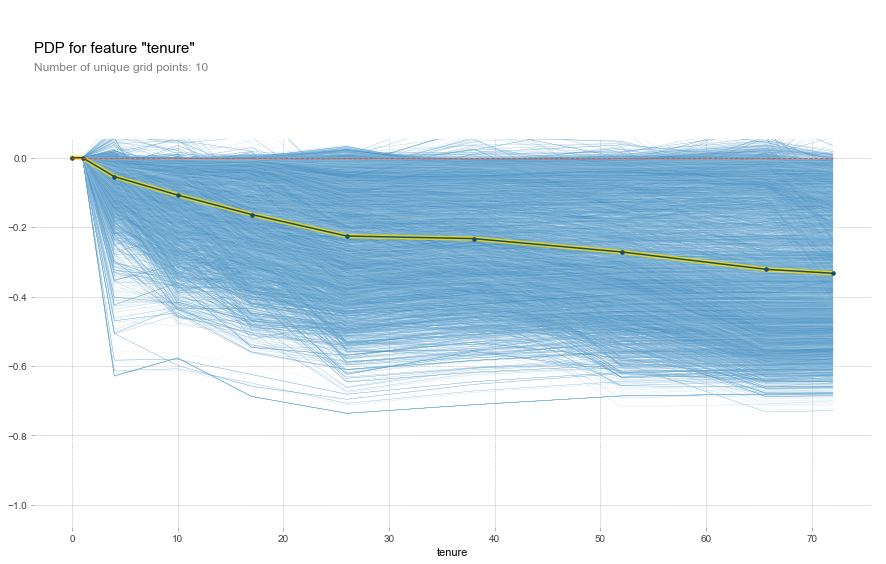

```python
plot_pdp('tenure')
```

## Training the final model

```python
X_train_final = pd.concat([X_train, X_val], axis=0)
y_train_final = pd.concat([y_train, y_val], axis=0)
```

```python
def reset_rf_samples():
    """ Undoes the changes produced by set_rf_samples.
    """
    forest._generate_sample_indices = (lambda rs, n_samples:
        forest.check_random_state(rs).randint(0, n_samples, n_samples))

reset_rf_samples()
```

```python
m = RandomForestClassifier(n_estimators=1000, min_samples_leaf=10, max_features=0.5, n_jobs=-1)
m.fit(X_train_final, y_train_final)
```

```
RandomForestClassifier(bootstrap=True, class_weight=None, criterion='gini',
            max_depth=None, max_features=0.5, max_leaf_nodes=None,
            min_impurity_decrease=0.0, min_impurity_split=None,
            min_samples_leaf=10, min_samples_split=2,
            min_weight_fraction_leaf=0.0, n_estimators=1000, n_jobs=-1,
            oob_score=False, random_state=None, verbose=0,
            warm_start=False)
```

```python
y_pred = m.predict(X_test)
```

```python
from sklearn.metrics import classification_report, confusion_matrix
print(classification_report(y_test, y_pred, target_names=['No churn', 'Churn']))
```

```
             precision    recall  f1-score   support

   No churn       0.88      0.80      0.84       561
      Churn       0.58      0.71      0.63       211

avg / total       0.80      0.78      0.78       772
```

```python
confusion_matrix(y_test, y_pred)
```

```
array([[451, 110],
       [ 62, 149]], dtype=int64)
```